# Processando a Informação: Cap. 1: Fundamentos

## Atividades no Moodle+VPL

Algumas atividades no Moodle+VPL pedem como entradas vetores de inteiros (ou reais), **armazenados em uma única linha**. Exemplo de entrada a ser lida:

### Entrada de Dados (cada linha contem um texto ou *string* incluindo os elementos do vetor e vários espaços ""):

```
7 3 7 9 7 7 0 9 8 4 8 9 0 1 7 8 4 1 1 0
2 1 9 4 3 6 0 9 8 4 2 8 0 6 7 3 2 4 5 9
```

Para não ter que incluir várias entradas inteiras, uma por linha, uma solução é fazer um método de leitura, passando como argumento um texto (*string*) referente a cada linha. Esse método deve retornar o vetor.

```python
%%writefile str2int.c
#include <stdio.h>
#include <string.h>
#include <stdlib.h>
int MAX=100, tamanho = 0;
void leiaVetor(int v[MAX], char string[]) {
   char * token = strtok(string, " ");
   while( token != NULL ) {
      v[tamanho++] = atoi(token); // converte texto para inteiro
      token = strtok(NULL, " ");
   }
}
int main() {
   char string[] = "7 3 7 9 7 7 0 9 8 4 8 9 0 1     7 8 4 1 1 0     ";
   int v[MAX];
   leiaVetor(v, string);
   for (int i=0;i<tamanho;i++ ){
     printf("%d ",v[i]);
   }
   return 0;
}
```

```python
%%shell
gcc -Wall -std=c99 str2int.c -o output2
./output2
```

[output not shown]

```python
%%writefile str2int.c
#include <stdio.h>
#include <string.h>
#include <stdlib.h>
int tamanho = 20;
// método para ler um vetor de inteiros digitado em uma linha, separados por espaços
int* leiaVetor(int n) {
  int* v = malloc(n * sizeof(int)); // aloca um vetor de n inteiros
  char texto[512]; // espaço para todos os números como um texto
  scanf("%[^\n]", texto); // lê todos os números como um texto
  char* token = strtok(texto, " "); // lê até o primeiro espaço na variável token
  int i = 0;
  while (token != NULL && i < n) {
    v[i++] = atoi(token); // guarda o valor convertido em numero no vetor e avança
    token = strtok(NULL, " "); // lê até ao próximo espaço a partir de onde terminou
  }
  return v;
}
int main() {
   //char string[] = "7 3 7 9 7 7 0 9 8 4 8 9 0 1     7 8 4 1 1 0     ";
   int * v = leiaVetor(tamanho);
   for (int i=0;i<tamanho;i++ ){
     printf("%d ",v[i]);
   }
   free(v); // libera memória alocada com malloc
   return 0;
}
```

```python
%%shell
gcc -Wall -std=c99 str2int.c -o output2
./output2
```

Utilizar [pythontutor.com](https://pythontutor.com/) para executar passo-a-passo esse código.

### Entrada de Dados (a linha contem um texto ou *string*):

```
A UFABC completou 15 anos!
```

Como contar as vogais de um texto?

## Revisão deste capítulo de Vetores

- Introdução

  > Vetores são estruturas para armazenar vários elementos de um mesmo tipo de dados em uma única variável.
- Trabalhando com vetores

  > Cada linguagem possui uma sintaxe própria para declarar e alocar vetores.
- Acessando elementos de um vetor

  > ATENÇÃO para não acessar uma posição do vetor não reservada/alocada, geralmente `<0` e `>=n`.
- Formas de percorrer um vetor

  > É possível varrer um vetor na forma ***raster*** e ***anti-raster***, também usando diferentes passos, mas geralmente é passo=1.
- Modularização e vetores

  > Muito útil usar principalmente os módulos de `leiaVetor` e `escrevaVetor`, podendo ser reaproveitados em vários códigos.
- Eficiência de Algortimos

  > Busca

  > Ordenação
- Exercícios
- Revisão deste capítulo de Vetores

## Processando a Informação: Cap. 5: Vetores - Prática 1

[figure not shown]

Este caderno (*Notebook*) é uma parte complementar *online* do livro **[Processando a Informação](https://editora.ufabc.edu.br/matematica-e-ciencias-da-computacao/58-processando-a-informacao): um livro prático de programação independente de linguagem**, que deve ser consultado em caso de dúvidas sobre os temas apresentados.

> Este conteúdo pode ser copiado e alterado livremente, sendo inspirado por este livro.

### Exercícios

[ref.: http://tiagodemelo.info/livros/logica/node4.html]

Ver simulações de vários algoritmos de ordenação: [link](https://www.toptal.com/developers/sorting-algorithms)

## Processando a Informação: Cap. 5: Vetores - Prática 2

[figure not shown]

Este caderno (*Notebook*) é uma parte complementar *online* do livro **[Processando a Informação](https://editora.ufabc.edu.br/matematica-e-ciencias-da-computacao/58-processando-a-informacao): um livro prático de programação independente de linguagem**, que deve ser consultado em caso de dúvidas sobre os temas apresentados.

> Este conteúdo pode ser copiado e alterado livremente, sendo inspirado por este livro.

### Exercícios

1. Criar um vetor de entrada com `n` posições com valores inteiros positivos e como saída criar um outro vetor também com `n` posições, onde a cada posição `i` seja atribuído a cálculo do mínimo do seu vizinho de `v1` à esquerda `i-1`, do próprio elemento `i` e do seu vizinho à direita `i+1`.
2. Criar um vetor com `n` posições com valores inteiros positivos e, como saída, criar um outro vetor também com `n` posições, onde em cada posição `i` seja atribuído a cálculo dos mínimos dos seus vizinhos de `v1` à esquerda `i-2` e `i-1`, do próprio elemento `i` e dos seus vizinhos à direita `i+1` e `i+2`. Generalize este código para os `m` vizinhos à esquerda e à direita.
3. O MMC (Mínimo Múltiplo Comum) de dois ou mais números inteiros é o menor múltiplo inteiro positivo comum a todos eles. Fazer uma função chamada MMC que recebe um vetor de números inteiros e retorna o MMC de todos. Veja um exemplo abaixo para calcular o MMC de 12 e 15:

[output not shown]

$$MMC = 60 = 2*2*3*5$$

4. Criar um vetor de inteiros com n elementos. Inverter este vetor sem usar vetor auxiliar.
5. Criar dois vetores de inteiros com n elementos cada. Calcular o produto escalar entre eles.

## Processando a Informação: Cap. 5: Vetores - Prática 3

[figure not shown]

Este caderno (*Notebook*) é uma parte complementar *online* do livro **[Processando a Informação](https://editora.ufabc.edu.br/matematica-e-ciencias-da-computacao/58-processando-a-informacao): um livro prático de programação independente de linguagem**, que deve ser consultado em caso de dúvidas sobre os temas apresentados.

> Este conteúdo pode ser copiado e alterado livremente, sendo inspirado por este livro.

### Exercícios

Fontes: [ref1](http://www.deinf.ufma.br/~csalles/prog/prog_lista2.pdf), [ref2](http://www.sistemas24horas.com.br/aulas/files_dic1/lista-exercicios-vetores-1.pdf), [ref3](https://fit.faccat.br/~fpereira/apostilas/exerc_resp_alg_mar2007.pdf), [ref4](https://docplayer.com.br/54457072-Laboratorio-de-programacao-a-exercicios-sobre-vetores-e-matrizes.html), [ref5](https://docplayer.com.br/21195395-Exercicios-vetores-e-matrizes.html)

1. Dado um vetor qualquer com $n$ números inteiros entre 0 e 9, faça um módulo que retorna o número que mais se repete.
2. Escreva um módulo que retira todos os números repetidos das primeiras N posições de um vetor em ordem crescente, colocando-os em ordem crescente no final do vetor. Exemplo: Para o vetor {1,2,2,3,3,4}, a solução é {1,2,3,4,2,3}.
3. Escreva um módulo que recebe um vetor lógico de 10 posições e oferece como resultado o produto da operação (((vet[0] E vet[1]) OU vet[2]) E vet[3]) ... e assim por diante.
4. Faça um programa que leia 30 valores do tipo inteiro e armazene-os em um vetor. A seguir, o programa deverá informar (1) todos os números pares que existem no vetor; (2) o menor e o maior valor existente no vetor; (3) quantos dos valores do vetor são maiores que a média desses valores.
5. Escreva um algoritmo que permita a leitura dos nomes de 10 pessoas e armaze os nomes lidos em um vetor. Após isto, o algoritmo deve permitir a leitura de mais 1 nome qualquer de pessoa e depois escrever a mensagem ACHEI, se o nome estiver entre os 10 nomes lidos anteriormente (guardados no vetor), ou NÃO ACHEI caso contrário.
6. Escreva um algoritmo que permita a leitura das notas de uma turma de 20 alunos. Calcular a média da turma e contar quantos alunos obtiveram nota acima desta média calculada. Escrever a média da turma e o resultado da contagem.
7. Ler um vetor Q de 20 posições (aceitar somente números positivos). Escrever a seguir o valor do maior (e menor) elemento de Q e a respectiva posição que ele ocupa no vetor.
8. Faça um algoritmo para ler um valor N qualquer (que será o tamanho dos vetores). Após, ler dois vetores A e B (de tamanho N cada um) e depois armazenar em um terceiro vetor Soma a soma dos elementos do vetor A com os do vetor B (respeitando as mesmas posições) e escrever o vetor Soma.
9. Faça um algoritmo para ler e armazenar em um vetor a temperatura média de todos os dias do ano. Calcular e escrever:
- Menor temperatura do ano
- Maior temperatura do ano
- Temperatura média anual
- O número de dias no ano em que a temperatura foi inferior a média anual
10. Faça um algoritmo para ler 10 números e armazenar em um vetor. Após isto, o algoritmo deve ordenar os números no vetor em ordem crescente. Depois de ordenar os elementos do vetor em ordem crescente, deve ser lido mais um número qualquer e inserir esse novo número na posição correta, ou seja,

mantendo a ordem crescente do vetor.

11. Faça um algoritmo para ler um vetor de 20 números. Após isto, deverá ser lido mais um número qualquer e verificar se esse número existe no vetor ou não. Se existir, o algoritmo deve gerar um novo vetor sem esse número. (Considere que não haverão números repetidos no vetor).
12. Faça um algoritmo para ler dois vetores V1 e V2 de 15 números cada. Calcular e escrever a quantidade de vezes que V1 e V2 possuem os mesmos números e nas mesmas posições (também, alterar para não ter essa última restrição).
13. Faça um programa que leia 2 vetores com 10 elementos cada. Considerando cada vetor como sendo um conjunto, crie um terceiro vetor, que seja a união dos dois primeiros, e um quarto, que seja a intersecção entre os dois primeiros.
14. Dado um vetor com números ordenados de forma não decrescente, faça uma função que imprime somente os números que não sejam repetidos.
15. Faça uma função que recebe dois vetores de inteiros, com qualquer número de elementos cada. Ela deve imprimir todos os valores presentes nos dois vetores. Ex: se v1={19, 5, 2, 6} e v2={5, 0, 9, 4, 18, 56} deverá ser impresso somente o valor 5.
16. Faça um programa que dado o vetor unidimensional [2; 4; 35; 50; 23; 17; 9; 12; 27; 5] retorne:
- maior valor
- média dos valores
- os valores dispostos em ordem crescente
- sub conjunto de valores primos que está contido no vetor
17. Faça um programa que:
- leia 7 valores inteiros e os armazene em um vetor. Listar o vetor com as referidasposições de armazenamento de cada valor.
- ofereça uma função de pesquisa onde dado um valor inteiro qualquer de entrada retornar a posição deste valor dentro do vetor, e caso este valor não esteja presente no vetor retornar –1.
- ofereça uma função que troque os valores contido no vetor pela seguinte política: cada elemento i dentro do vetor será substituído pela soma de todos os (i-1) elementos mais o elemento i. Por exemplo, dado um vetor [1; 2; 3; 4; 5] após a aplicação da função teríamos esse vetor preenchido com os seguintes valores [1;3; 6; 10; 15].
18. Escrever um programa para ler um vetor de 25 elementos do tipo inteiro e que, apósos valores serem lidos, verifique se existem números repetidos dentro do vetor. Caso exista, deverão ser informados quais são estes números e quantas vezes eles foram repetidos.
19. Escreva um programa em C para ler um vetor de 10 elementos inteiros. Excluir o1 o elemento do vetor deslocando os elementos subsequentes de uma posição parao inicio. Imprimir o vetor após a retirada do primeiro elemento.
20. Escreva um programa em C para ler um vetor X de 10 elementos e um valor P(aceitar apenas valores entre 0 e 9) que representa a posição de um elemento dentrodo vetor X. Imprimir o valor do elemento que ocupa a posição informada. Logo após excluir esse elemento do vetor fazendo com que os elementos subseqüentes (sehouverem) sejam deslocados de 1 posição para o inicio. Imprimir o vetor X após a exclusão ter sido executada.
21. Faça um programa que receba uma lista com nomes de alunos, as notas de cada aluno e a nota mínima para aprovação na disciplina. O aluno é considerado aprovadose a média de suas notas forma maior ou igual a nota mínima para aprovação. O programa deve informar uma lista de alunos aprovados e outra de alunos reprovados.
22. Escreva um programa para ler $n$ palavras. A seguir imprimir as palavras em ordem alfabética.
23. Escreva um programa para ler uma frase e contar o número de ocorrências de cada uma das 15 primeiras letras do alfabeto. Imprimir as contagens.
24. Escreva um programa para ler uma frase e uma letra. A seguir retirar da frase, todas as letras iguais a informada. Imprimir a frase modificada.
25. Escreva um programa para ler uma frase e contar o número de palavras existentes na frase. Considere palavra um conjunto qualquer de caracteres separados por um conjunto qualquer de espaços em branco.
26. Escreva um programa que leia n números inteiros no intervalo [0,50] e os armazeneem um vetor estaticamente alocado com 100 posições. Preencha um segundo vetor, também alocado estaticamente, apenas com os números ímpares do primeiro vetor. Imprima os dois vetores, 10 elementos por linha.
27. Leia 10 números inteiros e armazene em um vetor v. Crie dois novos vetores v1 e v2. Copie os valores ímpares de v para v1, e os valores pares de v para v2. Note que cada um dos vetores v1 e v2 têm no máximo 10 elementos, mas nem todos os elementos são utilizados. No final escreva os elementos UTILIZADOS de v1 e v2.
28. Faça um programa para ler 10 números DIFERENTES a serem armazenados em um vetor. Os dados deverão ser armazenados no vetor na ordem que forem sendo lidos, sendo que caso o usuário digite um número que já foi digitado anteriormente, o programadeverá pedir para ele digitar outro número. Note que cada valor digitado pelo usuário deve ser pesquisado no vetor, verificando se ele existe entre os números que já foram fornecidos. Exibir na tela o vetor final que foi digitado.
29. Faça um programa que leia dez conjuntos de dois valores, o primeiro representando o número do aluno e o segundo representando a sua altura em metros. Encontre o aluno mais baixo e o mais alto. Mostre o número do aluno mais baixo e do mais alto, juntamente com suas alturas.
30. Faça um programa que leia dois números a e b (positivos menores que 10000) e:Crie um vetor onde cada posição é um algarismo do número. A primeira posição é o algarismo menos significativo;Crie um vetor que seja a soma de a e b, mas faça-o usando apenas os vetores construídos anteriormente. Dica: some as posições correspondentes. Se a soma ultrapassar 10, subtraia 10 do resultado e some 1 à próxima posição.
31. Faça um programa que leia dois números n e m e:Crie e leia um vetor de inteiros de n posições;Crie e leia um vetor de inteiros de m posições;Crie e construa um vetor de inteiros que seja a interseção entre os dois vetores anteriores, ou seja, que contém apenas os números que estão em ambos os vetores.Crie e construa um quarto vetor de inteiros que seja a uniãoo entre os dois vetores anteriores lidos, ou seja, que contém os elementos dos dois vetores.
32. Faça um programa que receba o nome de $n$ clientes e armazene-os em um vetor. Em um segundo vetor, armazene a quantidade de DVDs locados em 2009 por cada um dos clientes. Sabe-se que, para cada dez locações, o cliente tem direito a uma locação grátis. Faça um programa que mostre o nome de todos os clientes, com a quantidade de locações grátis a que ele tem direito.
33. Faça um programa que preencha três vetores com $n$ posições cada um: o primeiro vetor, com os nomes dos produtos; o segundo vetor, com os códigos dos produtos; e o terceiro vetor; com os preços dos produtos. Mostre um relatório apenas com o nome, o código, o preço e o novo preço dos produtos que sofrerão aumento. Sabe-se que os produtos que sofrerão aumento são aqueles que possuem código par ou preço superiora R$ 1.000,00. Sabe-se ainda que, para os produtos que satisfizerem às duas condições anteriores, código e preço, o aumento será de 20%; para aqueles que satisfazerem apenas a condição de código, o aumento será de 15%; e aqueles que satisfazerem apenas a condição de preço, o aumento será de 10%.
34. Faça um vetor de tamanho 50 preenchido com o seguinte valor: $(i+5i)\%i$, sendo $i$ aposição do elemento no vetor, em seguida imprima o vetor na tela.
35. Faça um programa que calcule o desvio padrão (STD) de um vetor $v$ contendo $n$ números, ondem $m$ a média do vetor.

$$ STD = \sqrt{\frac{1}{n-1} \sum_{i=0}^{n-1}(v[i]-m)^2} $$

# Processando a Informação: Cap. 6: Matrizes

[figure not shown]

Este caderno (*Notebook*) é uma parte complementar *online* do livro **[Processando a Informação](https://editora.ufabc.edu.br/matematica-e-ciencias-da-computacao/58-processando-a-informacao): um livro prático de programação independente de linguagem**, que deve ser consultado em caso de dúvidas sobre os temas apresentados.

> Este conteúdo pode ser copiado e alterado livremente, sendo inspirado por este livro.

## Sumário

- Revisão do capítulo anterior
- Introdução
- Instanciando matrizes
- Acessando elementos de uma matriz
- Formas de percorrer uma matriz
- Aplicações usando matrizes
- Revisão deste capítulo
- Exercícios

## Revisão do capítulo anterior (Vetores)

- Introdução

  > Vetores são estruturas para armazenar vários elementos de um mesmo tipo de dados em uma única variável.
- Trabalhando com vetores

  > Cada linguagem possui uma sintaxe própria para declarar e alocar vetores.
- Acessando elementos de um vetor

  > **ATENÇÃO** para não acessar uma posição do vetor não reservada/alocada, geralmente `<0` e `>=n`.
- Formas de percorrer um vetor

  > É possível varrer um vetor na forma ***raster*** e ***anti-raster***, também usando diferentes passos, mas geralmente é passo=1.
- Modularização e vetores

  > Muito útil usar principalmente os módulos de `leiaVetor` e `escrevaVetor`, podendo ser reaproveitados em vários códigos.
- Tudo que foi visto no capítulo anterior de **Vetores** (ou estruturas **unidimensional** ou **1D**) se estende a estrutura de **Matrizes** (ou estruturas **bidimensional** ou **2D)**).

## Introdução

- Existem situações em que é necessário estender a definição de vetor para mais de uma dimensão de dados.
- Por exemplo, uma forma muito utilizada de manipulação de dados é em tabelas.
- Como exemplo, para listar todos os alunos de uma turma e suas notas em uma disciplina:
  - As linhas da tabela podem armazenar a identificação dos alunos na primeira coluna.
  - Nas colunas seguintes, podem armazenar as notas da prova1, prova2, projeto e, numa última coluna, podem armazenar a nota final do aluno.
- Analogamente a um vetor, em uma matriz cada elemento possui apenas um dado.
- Além disso, na maioria das linguagens de programação, todos os elementos de uma matriz são de um mesmo tipo de dado.
- Um outro exemplo de matrizes muito usado, especialmente com a popularização dos dispositivos móveis como celulares e *tablets*, que comumente trazem câmeras digitais acopladas, ocorre no armazenamento e *Processamento Digital de Imagens*.
- Mas antes das câmeras digitais, já havia *scanners* e digitalizadores, e uma imagem pode ser representada por uma **matriz** em um computador.
- Veja o conteúdo no ***QRCode*** (imagem pode ser representada por uma matriz) abaixo usando um aplicativo leitor de QRCode, disponível para *Smartphones* (teste nesta imagem).
- O conteúdo do ***QRCode*** direciona para uma página *web* mostrando uma imagem colorida.
- As imagens coloridas podem ser armazenadas em uma estrutura de matriz **tridimensional**, onde cada dimensão armazena uma matriz para uma cor primária (RGB - *Red-Green-Blue* ou vermelho, verde e azul).

[figure not shown]

[figure not shown]

## Instanciando Matrizes

- Nas linguagens MatLab e R, uma matriz é definida com elementos da posição `(1,1)` até a posição `(L, C)`, onde `L` representa o número de linhas e `C` representa o número de colunas de uma matriz.
- Na maioria das linguagens de programação, no entanto, o índice começa no zero, sendo os elementos de uma matriz armazenados da posição `(0,0)` até `(L-1,C-1)`.
- Nos exemplos a seguir, são apresentados alguns exemplos de instanciação de matrizes.

## Acessando elementos de uma matriz

- Uma matriz está pronta para inserir elementos ou alterar seus dados após ser instanciada e alocada na memória, em todas as suas dimensões.
- Veja uma forma de visualizar uma matriz 2D na Figura abaixo.

[figure not shown]

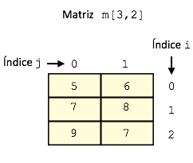

- Essa figura ilustra uma matriz com `3` linhas e `2` colunas.
- Para visualizar seus elementos, podemos usar os índices `i` e `j`,
  - com valores para as linhas `0 <= i < 3` e
  - para as colunas `0 <= j < 2`.
- Analogamente ao vetor, mas com uma dimensão a mais, a matriz recebe valores para os seus elementos, conforme a seguinte estrutura em pseudocódigo:

```
Pseudocódigo:
Instanciar uma matriz m com 3 linhas e 2 colunas
m[0,0] = 5 # linha i=0
m[0,1] = 6
m[1,0] = 7 # linha i=1
m[1,1] = 8
m[2,0] = 9 # linha i=2
m[2,1] = 7
```

## Formas de se percorrer uma matriz

- Analogamente ao vetor, uma matriz, após criada, possui tamanho fixo.
- Geralmente, para cada dimensão da matriz, é recomendado usar uma estrutura de repetição `para`,

  > com o objetivo de tornar o código mais compacto e genérico para matrizes de quaisquer dimensões.
- Além disso, é natural percorrer (ou varrer) a matriz
  - da linha `i=0` até a linha `i<L`, onde `L` representa o número de linhas de uma matriz.
  - e da coluna `j=0` até a coluna `j<C`, onde `C` representa o número de colunas de uma matriz.
- No exemplo a seguir em pseudocódigo, uma matriz `m` é criada com `6` elementos, sendo três linhas e `2` colunas, e os dois laços `para` inicializam todos os seus elementos com o valor 0.

```
Pseudocódigo:
Instanciar uma matriz m com 3 linhas e 2 colunas
inteiros L=3, C=2
Para cada i, de i=0; até i<L; passo i=i+1 faça
    Para cada j, de j=0; até j<C; passo j=j+1 faça
        m[i,j] = 0
```

- Existem várias formas de percorrer (ou varrer) uma matriz usando uma estrutura de repetição.
- Por exemplo, é possível percorrer uma matriz
  - do primeiro elemento `m[0,0]`

  > (convencionando como canto superior esquerdo)
  - até o último elemento `m[L-1,C-1]`

    > (convencionando como canto inferior direito da matriz),
  - linha por linha, ou coluna por coluna.
- Esse tipo de varredura é chamada **raster**.
- A varredura inversa é chamada **anti-raster**, do último elemento inferior direito até o primeiro elemento superior esquerdo.

## Exemplo 01 - Ler/Escrever matriz

- Analogamente ao que foi feito no capítulo anterior sobre vetores, onde alocamos os vetores em tempo de execução através de métodos, é possível usar modularização para melhorar a organização, manutenção e reaproveitamento de código.
- Aqui é apresentado um método `leiaMatriz` e `escrevaMatriz` genéricos.
  - Para entrada de dados (`leiaMatriz`), ou seja, inserir valores nos elementos alocados na memória para uma matriz.
  - Além de saída de dados (`escrevaMatriz`), para escrever a matriz, linha por linha.

#### Pseudocódigo

**Exemplo 01:** Considere um algoritmo para:

- Ler um inteiro `L` (linhas) representando o número de alunos.
- Ler um inteiro `C` representando o número de avaliações.
- Considere a primeira coluna como o `RA` do aluno, assim `C = C + 1`.
- Criar uma matriz `m` com dimensões `LxC`.
- Ler todos os elementos da matriz.
- Escrever todos os elementos da matriz, formando a saída linha por linha. Por exemplo, para uma matriz com `2` alunos e `3` avaliações, escreva:

```
LISTA DE ALUNOS vs Avaliações:
1234 4 3 9
3456 6 4 8
```

```
Método Real[][] leiaMatriz(inteiro L, inteiro C):
    Instanciar e alocar uma matriz m de Reais com L x C
    Para cada i, de i=0; até i<L; passo i=i+1 faça
        Para cada j, de j=0; até j<C; passo j=j+1 faça
            m[i,j] = leiaReal("Digite um número real:");

Método escrevaMatriz(Real m[][], inteiro L, inteiro C):
    Para cada i, de i=0; até i<L; passo i=i+1 faça
        Para cada j, de j=0; até j<C; passo j=j+1 faça
            escreva(" ", m[i,j]);
        escreva("\n"); // pula linha

// PROGRAMA PRINCIPAL
// ENTRADAS
inteiro L = leia("Digite o número de alunos:");
inteiro C = leia("Digite o número de avaliações:");
C = C + 1;  // a primeira coluna é o RA
Instanciar uma matriz m com L linhas e C colunas

m = leiaMatriz(L, C)
// PROCESSAMENTO: ?

// SAÍDA
escrevaMatriz(m, L, C)
```

#### Casos para Teste Moodle+VPL

Para o professor criar uma atividade VPL no Moodle para este Exemplo 01, basta incluir em `Casos para teste`, o seguinte texto (pode incluir mais casos):

[output not shown]

```python
%%writefile cap6ex01.java

import java.util.Scanner;

public class cap6ex01 {

    static Scanner scan = new Scanner(System.in);

    public static void main(String[] args) {

        // ENTRADA DE DADOS
        System.out.print("Digite o numero de alunos:");
        int L = scan.nextInt();        // lê número de linhas
        System.out.print("Digite o numero de avaliações:");
        int C = scan.nextInt();        // lê número de colunas
        int m[][]; // declara

        C = C + 1; // a primeira coluna é o RA do aluno

        System.out.println("Entre com os elementos da matriz:");
        m = leiaMatriz(L,C);

        // PROCESSAMENTO: ?

        // SAÍDA DE DADOS
        System.out.print("LISTA DE ALUNOS vs Avaliações:\nRA");
        for (int i = 0; i < C-1; i++) {
            System.out.printf("%4d", i+1);
        }
        System.out.println();
        escrevaMatriz(m);
    }

    static int[][] leiaMatriz(int L, int C) {
      // leitura dos LxC elmentos da matriz m
      int m[][] = new int[L][C];
      for (int i = 0; i < m.length; i++)         // linhas i
          for (int j = 0; j < m[0].length; j++)  // coluna j
            m[i][j] = scan.nextInt();
            // lê elemento i,j
      return m;
    }

    static void escrevaMatriz(int m[][]) {
      // imprimir matriz (cada linha de m em uma linha)
      for (int i = 0; i < m.length; i++) {       // linha  i
          for (int j = 0; j < m[0].length; j++)  // coluna j
              System.out.printf("%4d", m[i][j]); // formatada
          System.out.println();                  // pula linha
      }
    }
}
```

```python
!javac cap6ex01.java
!java cap6ex01
```

```python
# solução 1
%%writefile cap6ex01.js
function escreva(s) {try {element.append(s)} catch(e) {try {document.write(s)} catch(e) {console.log(s)}}}
const leia = (name) => {return `${name}`}

function leiaMatriz(L,C,contaLinhas) {
  var m = [];
  for(var i=0; i < L; i++){  // Creates all lines:
      m.push([]);  // Creates an empty line
      m[i].push( new Array(C)); // Adds cols to the empty line:
      for(var j=0; j < C; j++){
        m[i][j] = parseInt(leia(process.argv[contaLinhas])) // ATENÇÃO NESTA INSTRUÇÃO!
        contaLinhas++
      }
  }
  return m;
}
function escrevaMatriz(m) {
  s = ''
  for (i=0; i<m.length; i++) {
    for (j=0; j<m[0].length; j++) {
      s += m[i][j] + "\t";
    }
    s += "\n"
  }
  escreva(s)
}

// ENTRADAS
escreva("Digite o numero de alunos: ")
var L = parseInt(leia(process.argv[2]))    // ATENÇÃO NESTA INSTRUÇÃO!
escreva("Digite o numero de avaliações: ")
var C = parseInt(leia(process.argv[3]))    // ATENÇÃO NESTA INSTRUÇÃO!

C = C + 1; // a primeira coluna é o RA do aluno

contaLinhas = 4;  // ATENÇÃO NESTA INSTRUÇÃO!
m = leiaMatriz(L,C,contaLinhas)

// PROCESSAMENTO ?
// SAÍDA DE DADOS
escreva("LISTA DE ALUNOS vs Avaliações:");
var s = "RA"
for (i = 0; i < C-1; i++) {
  s +="\t"+(i+1)
}
escreva(s)
escrevaMatriz(m)
```

```python
%%shell
node cap6ex01 2 2 2345 5 9 9834 9 7
```

[output not shown]

Código para executar em antividades no Moodle+VPL. Testar códigos antes de submeter para avaliação, por exemplo, em https://www.jdoodle.com/execute-nodejs-online.

```python
# solução 2: para executar no Moodle+VPL
%%writefile cap6ex01.js
function escreva(s) {try {element.append(s)} catch(e) {try {document.write(s)} catch(e) {console.log(s)}}}
function leia(linhas,i) {return linhas.toString().split('\n')[i]}

function leiaMatriz(linhas,L,C,contaLinhas) {
  var m = [];
  for(var i=0; i < L; i++){  // Creates all lines:
      m.push([]);  // Creates an empty line
      m[i].push( new Array(C)); // Adds cols to the empty line:
      for(var j=0; j < C; j++){
        m[i][j] = parseInt(leia(linhas,contaLinhas)) // ATENÇÃO NESTA INSTRUÇÃO!
        contaLinhas++
      }
  }
  return m;
}
function escrevaMatriz(m) {
  s = ''
  for (i=0; i<m.length; i++) {
    for (j=0; j<m[0].length; j++) {
      s += m[i][j] + "\t";
    }
    s += "\n"
  }
  escreva(s)
}

process.stdin.once('data', linhas => {
  // ENTRADAS
  escreva("Digite o numero de alunos: ")
  var L = parseInt(leia(linhas,0))    // ATENÇÃO NESTA INSTRUÇÃO!
  escreva("Digite o numero de avaliações: ")
  var C = parseInt(leia(linhas,1))    // ATENÇÃO NESTA INSTRUÇÃO!

  C = C + 1; // a primeira coluna é o RA do aluno

  contaLinhas = 2;  // ATENÇÃO NESTA INSTRUÇÃO!
  m = leiaMatriz(linhas,L,C,contaLinhas)

  // PROCESSAMENTO ?
  // SAÍDA DE DADOS
  escreva("LISTA DE ALUNOS vs Avaliações:");
  var s = "RA"
  for (i = 0; i < C-1; i++) {
    s +="\t"+(i+1)
  }
  escreva(s)
  escrevaMatriz(m)
})
```

```python
# NÃO executa NESTE COLAB, SOMENTE NO MOODLE+VPL
%%shell
#node cap6ex01 2 2 2345 5 9 9834 9 7
```

```python
%%writefile cap6ex01.c
#include <stdio.h>
#include<malloc.h>

int ** leiaMatriz(int L, int C) {
  int **m = (int **)malloc(L*sizeof(int*));
  for (int i = 0; i < L; i++) {
    m[i] = (int *)malloc(C * sizeof(int)); // for each row allocate C ints
    for (int j = 0; j < C; j++)
      scanf("%d", &m[i][j]);
  }
  return m;
}
void free_matrix(int **m, int L) {
    for (int i = 0; i < L; i++)
         free(m[i]);
    free(m);
 }
void escrevaMatriz(int **m, int L, int C) {
  for (int i = 0; i < L; i++) {
   for (int j = 0; j < C; j++)
      printf("%d\t", m[i][j]);
   printf("\n");
  }
}
int main(void) {
  // ENTRADA DE DADOS
  int L, C, **m;   // variaveis de referência m
  printf("Digite o número de alunos: ");
  scanf("%d", &L);

  printf("Digite o número de avaliações: ");
  scanf("%d", &C);

  C = C + 1; // a primeira coluna é o RA do aluno

  printf("Digite os elementos da matriz");
  m = leiaMatriz(L,C);

  // PROCESSAMENTO ?

  // SAÍDA DE DADOS
  printf("\nLISTA DE ALUNOS vs Avaliações:\n");
  printf("RA ");
  for (int i = 0; i < C-1; i++)
    printf("\t%d",(i+1));

  printf("\n");
  escrevaMatriz(m,L,C);
  free_matrix(m,L); // liberar memória alocado com malloc
  return 0;
}
```

```python
%%shell
gcc -Wall -std=c99 cap6ex01.c -o output2
./output2
```

##### Acessando elemento com `*`

Outras forma de acessar elementos em matriz.

```
  for (int i = 0; i < L; i++)
   for (int j = 0; j < C; j++) {
      printf("%d\t", m[i][j]); // ou
      printf("%d\t", *(m + i*C + j));
   }
```

Ou utilizando apenas um laço para varrar uma matriz:

```
  for (int i = 0; i < L*C; i++) {
      printf("%d\t", m[i/C][i%C]); // ou
      printf("%d\t", *(m + i));
   }
```

##### Matriz Multimensional

```
for (int k = 0; k < D; k++) // profundidade
  for (int i = 0; i < L; i++) // linha
   for (int j = 0; j < C; j++) { // coluna
      printf("%d\t", m[k][i][j]); // ou
      printf("%d\t", *(m + k*L*C + i*C + j));
   }
```

Ou utilizando apenas um laço para varrar uma matriz:

```
  for (int i = 0; i < D*L*C; i++) {
      d = i/(L*C);
      printf("%d\t", m[d][(d-i)/C][(d-i)%C]); // ou
      printf("%d\t", *(m + i));
   }
```

## Exercícios

Ver notebook Colab nos arquivos `cap6.partX.lab.*.ipynb` (`X` $\in$ `[2,3,4,5]` e `*` é a extensão da linguagem), utilizando alguma linguagem de programação de sua preferência, onganizadas em subpastas contidas em `"gen"`, na pasta do Google Drive [colabs](https://drive.google.com/drive/folders/1YlFwv8XYN7PYYf-HwDMlkxzbmXzJw9cM?usp=sharing).

## Atividades no Moodle+VPL

Algumas atividades no Moodle+VPL pedem como entradas matrizes de inteiros (ou reais), **armazenados em várias linhas**. Exemplo de entrada a ser lida:

### Entrada de Dados (cada linha contem um texto ou *string* com elementos da linha da matriz e vários espaços ""):

```
0 9 3 6 9 8 4 5 4
8 1 2 3 5 2 9 9 6
4 1 1 0 9 9 8 2 7
5 2 8 4 6 6 0 8 0
4 7 6 4 3 9 3 3 5
2 6 0 4 0 7 5 5 2
9 8 4 8 4 7 1 4 3
```

Para não ter que incluir várias entradas inteiras, a melhor solução é fazer um método de leitura, passando como argumento um texto (*string*) com várias linhas. O final de cada linha é definido por `\n`, e o final da matriz deve ser uma linha em branco com apenas `\n`. Esse método deve retornar a matriz.

## Revisão deste capítulo de Matriz

- Introdução
- Instanciando matrizes
- Acessando elementos de uma matriz
- Formas de percorrer uma matriz
- Aplicações usando matrizes
- Exercícios
- Revisão deste capítulo de Matriz

## Processando a Informação: Cap. 6: Matrizes - Prática 1

[figure not shown]

Este caderno (*Notebook*) é uma parte complementar *online* do livro **[Processando a Informação](https://editora.ufabc.edu.br/matematica-e-ciencias-da-computacao/58-processando-a-informacao): um livro prático de programação independente de linguagem**, que deve ser consultado em caso de dúvidas sobre os temas apresentados.

> Este conteúdo pode ser copiado e alterado livremente, sendo inspirado por este livro.

### Exercícios

1. Criar uma matriz para armazenar as `C` notas de uma turma e calcular a média de cada aluno, considerando uma turma com `L` alunos.
2. Em complemento ao exercício anterior, criar também um vetor de String, onde para cada posição `0<=i<L` seja armazenada a palavra `"reprovado"` se a nota for abaixo de 5, ou `"aprovado"`, caso contrário.
3. Criar uma matriz para armazenar `L` linhas e `C` colunas. Calcular e exibir a soma dos elementos da diagonal principal e secundária da matriz.
4. Criar uma matriz para armazenar `L` linhas e `C` colunas. Calcular a soma dos elementos acima da diagonal da matriz.
5. Criar uma matriz `m1` para armazenar `L` linhas e `C` colunas. Criar uma outra matriz `m2` para armazenar `m1` transposta, com `C` linhas e `L` colunas, sendo que a primeira linha de `m2` contenha os elementos da primeira coluna de `m1`. Isso se repete para as demais linhas de `m2` e colunas de `m1`.

## Processando a Informação: Cap. 6: Matrizes - Prática 2

[figure not shown]

Este caderno (*Notebook*) é uma parte complementar *online* do livro **[Processando a Informação](https://editora.ufabc.edu.br/matematica-e-ciencias-da-computacao/58-processando-a-informacao): um livro prático de programação independente de linguagem**, que deve ser consultado em caso de dúvidas sobre os temas apresentados.

> Este conteúdo pode ser copiado e alterado livremente, sendo inspirado por este livro.

### Exercícios

1. Criar uma função/método para calcular e retornar o determinante de uma matriz `3 x 3` de valores reais recebida como parâmetro.
2. Criar um método que receba uma matriz qualquer de inteiros e imprima na tela o valor máximo e o valor mínimo encontrados (não retornando nada).
3. Criar um método que receba uma matriz de inteiros de qualquer dimensão e retorne um vetor contendo a somatória dos valores contidos nas colunas.

4.Considere:

- a) Criar um método que receba uma matriz `m1` de inteiros positivos com `L` linhas e `C` colunas e retorne uma matriz `m2`, de mesma dimensão, onde em cada posição `[i,j]` seja atribuído o cálculo dos máximos entre o elemento de `m1` e seus oito vizinhos:

[output not shown]

- b) Generalize este código para os `m` vizinhos da `m1` à esquerde e à direita e os n vizinhos acima e abaixo.
5. Criar um método que receba duas matrizes de valores reais e retorne à multiplicação das duas matrizes.